# Group_11_Segmentation

**Objective:** To understand and gain insights from a retail dataset by performing various exploratory data analyses, data visualization, and data modelling.

**Dataset Columns:**

- **InvoiceNo:** Invoice number. A unique number per invoice.
- **StockCode:** Product code. A unique number per product.
- **Description:** Product description.
- **Quantity:** The number of products sold per invoice.
- **InvoiceDate:** The date and time of the invoice.
- **UnitPrice:** The price of one unit of the product.
- **CustomerID:** Customer identification number.
- **Country:** The country where the customer resides.

## 1. Data Preprocessing and Cleaning:

1.1. Import necessary libraries and read the dataset:

```python
import pandas as pd
import matplotlib.pyplot as plt
import seaborn as sns
import warnings
warnings.filterwarnings("ignore")

df = pd.read_csv('Sales_data.csv', encoding='ANSI')
```

```python
import numpy as np
import sklearn
```

1.2. Display the top 10 rows of the dataframe:

```python
df.head(10)
```

|  | InvoiceNo | StockCode | Description | Quantity | InvoiceDate | UnitPrice | CustomerID | Country |
| --- | --- | --- | --- | --- | --- | --- | --- | --- |
| 0 | 536365 | 85123A | WHITE HANGING HEART T-LIGHT HOLDER | 6 | 12/1/2010 8:26 | 2.55 | 17850.0 | United Kingdom |
| 1 | 536365 | 71053 | WHITE METAL LANTERN | 6 | 12/1/2010 8:26 | 3.39 | 17850.0 | United Kingdom |
| 2 | 536365 | 84406B | CREAM CUPID HEARTS COAT HANGER | 8 | 12/1/2010 8:26 | 2.75 | 17850.0 | United Kingdom |
| 3 | 536365 | 84029G | KNITTED UNION FLAG HOT WATER BOTTLE | 6 | 12/1/2010 8:26 | 3.39 | 17850.0 | United Kingdom |
| 4 | 536365 | 84029E | RED WOOLLY HOTTIE WHITE HEART. | 6 | 12/1/2010 8:26 | 3.39 | 17850.0 | United Kingdom |
| 5 | 536365 | 22752 | SET 7 BABUSHKA NESTING BOXES | 2 | 12/1/2010 8:26 | 7.65 | 17850.0 | United Kingdom |
| 6 | 536365 | 21730 | GLASS STAR FROSTED T-LIGHT HOLDER | 6 | 12/1/2010 8:26 | 4.25 | 17850.0 | United Kingdom |
| 7 | 536366 | 22633 | HAND WARMER UNION JACK | 6 | 12/1/2010 8:28 | 1.85 | 17850.0 | United Kingdom |
| 8 | 536366 | 22632 | HAND WARMER RED POLKA DOT | 6 | 12/1/2010 8:28 | 1.85 | 17850.0 | United Kingdom |
| 9 | 536367 | 84879 | ASSORTED COLOUR BIRD ORNAMENT | 32 | 12/1/2010 8:34 | 1.69 | 13047.0 | United Kingdom |

```python
df.info()
```

```
<class 'pandas.core.frame.DataFrame'>
RangeIndex: 541909 entries, 0 to 541908
Data columns (total 8 columns):
 #   Column       Non-Null Count   Dtype
---  ------       --------------   -----
 0   InvoiceNo    541909 non-null  object
 1   StockCode    541909 non-null  object
 2   Description  540455 non-null  object
 3   Quantity     541909 non-null  int64
 4   InvoiceDate  541909 non-null  object
 5   UnitPrice    541909 non-null  float64
 6   CustomerID   406829 non-null  float64
 7   Country      541909 non-null  object
dtypes: float64(2), int64(1), object(5)
memory usage: 33.1+ MB
```

1.3. Check for missing values:

```python
missing_values = df.isnull().sum()
print(missing_values)
```

```
InvoiceNo           0
StockCode           0
Description      1454
Quantity            0
InvoiceDate         0
UnitPrice           0
CustomerID     135080
Country             0
dtype: int64
```

1.4. Convert the InvoiceDate column to datetime format:

```python
df['InvoiceDate'] = pd.to_datetime(df['InvoiceDate'])
```

1.5. Add a new column 'TotalPrice' to the dataframe which is the product of 'UnitPrice' and 'Quantity':

```python
#df['Quantity'] = df['Quantity'].abs()
#df['UnitPrice'] = df['UnitPrice'].abs()
```

```python
df['TotalPrice'] = df['UnitPrice'] * df['Quantity']
df.head()
```

|  | InvoiceNo | StockCode | Description | Quantity | InvoiceDate | UnitPrice | CustomerID | Country | TotalPrice |
| --- | --- | --- | --- | --- | --- | --- | --- | --- | --- |
| 0 | 536365 | 85123A | WHITE HANGING HEART T-LIGHT HOLDER | 6 | 2010-12-01 08:26:00 | 2.55 | 17850.0 | United Kingdom | 15.30 |
| 1 | 536365 | 71053 | WHITE METAL LANTERN | 6 | 2010-12-01 08:26:00 | 3.39 | 17850.0 | United Kingdom | 20.34 |
| 2 | 536365 | 84406B | CREAM CUPID HEARTS COAT HANGER | 8 | 2010-12-01 08:26:00 | 2.75 | 17850.0 | United Kingdom | 22.00 |
| 3 | 536365 | 84029G | KNITTED UNION FLAG HOT WATER BOTTLE | 6 | 2010-12-01 08:26:00 | 3.39 | 17850.0 | United Kingdom | 20.34 |
| 4 | 536365 | 84029E | RED WOOLLY HOTTIE WHITE HEART. | 6 | 2010-12-01 08:26:00 | 3.39 | 17850.0 | United Kingdom | 20.34 |

## 2. Exploratory Data Analysis:

2.1. How many unique products are there in the dataset?

```python
unique_products = df['StockCode'].nunique()
print(unique_products)
```

```
4070
```

2.2. Which are the top 10 products (using StockCode) sold by quantity?

```python
top_products = df.groupby('StockCode').agg({'Quantity': 'sum', 'Description': 'last'}).sort_values(by='Quantity', ascending=False).head(10)
print(top_products[['Quantity', 'Description']])
```

```
           Quantity                         Description
StockCode
22197         56450                      POPCORN HOLDER
84077         53847   WORLD WAR 2 GLIDERS ASSTD DESIGNS
85099B        47363             JUMBO BAG RED RETROSPOT
85123A        38830  CREAM HANGING HEART T-LIGHT HOLDER
84879         36221       ASSORTED COLOUR BIRD ORNAMENT
21212         36039     PACK OF 72 RETROSPOT CAKE CASES
23084         30646                  RABBIT NIGHT LIGHT
22492         26437             MINI PAINT SET VINTAGE
22616         26315          PACK OF 12 LONDON TISSUES
21977         24753  PACK OF 60 PINK PAISLEY CAKE CASES
```

2.3. How many unique customers are there in the dataset?

```python
unique_customers = df['CustomerID'].nunique()
print(unique_customers)
```

```
4372
```

2.4. Which country has the maximum number of unique customers?

```python
top_country = df.groupby('Country')['CustomerID'].nunique().idxmax()
print(top_country)
```

```
United Kingdom
```

2.5. Visualize the distribution of 'TotalPrice' using a density plot.

```python
df['TotalPrice'].max()
```

```
168469.6
```

```python
count_uk = df[df['Country'] == 'United Kingdom'].shape[0]
print("Count of rows with 'Country' as 'United Kingdom':", count_uk)
print('UK Proportion:',count_uk/df.shape[0])
```

```
Count of rows with 'Country' as 'United Kingdom': 495478
UK Proportion: 0.9143195628786382
```

```python
count_uk = df[df['Country'] == 'Netherlands'].shape[0]
print("Count of rows with 'Country' as 'United Kingdom':", count_uk)
print('UK Proportion:',count_uk/df.shape[0])
```

[output not shown]

```python
top_countries = df[df['CustomerID'].notnull()]  # Filter out rows with missing CustomerID
country_counts = top_countries['Country'].value_counts()
total_customers = country_counts.sum()
top_5_countries = country_counts.head(5)
top_5_countries_percentage = (top_5_countries / total_customers) * 100

print("Top 5 Countries based on Customer Count:")
print(top_5_countries)
print("\nPercentage of Customers in Each Country:")
print(top_5_countries_percentage)
```

```
Top 5 Countries based on Customer Count:
United Kingdom    361878
Germany             9495
France              8491
EIRE                7485
Spain               2533
Name: Country, dtype: int64

Percentage of Customers in Each Country:
United Kingdom    88.950886
Germany            2.333904
France             2.087118
EIRE               1.839839
Spain              0.622620
Name: Country, dtype: float64
```

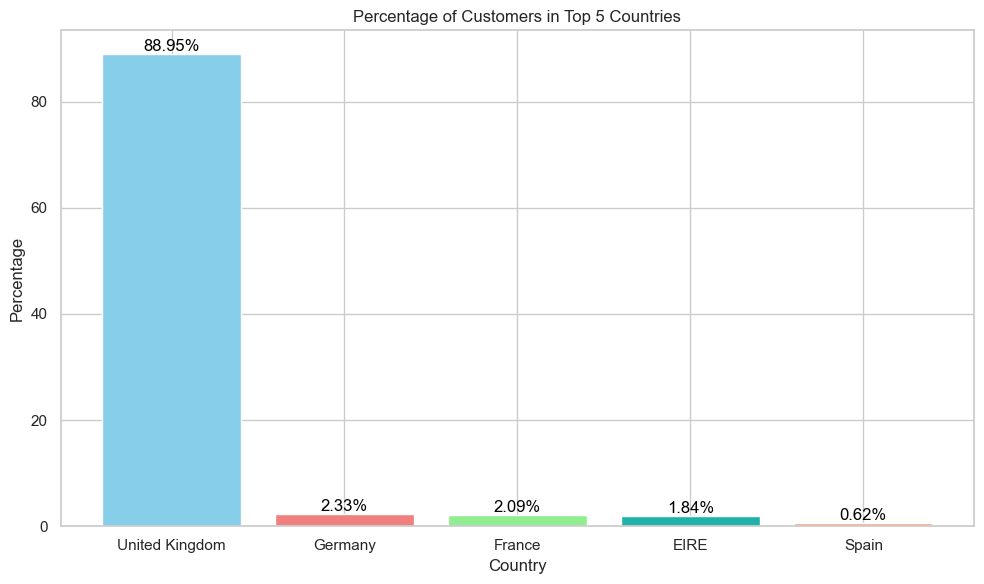

```python
countries = top_5_countries_percentage.index
percentages = top_5_countries_percentage.values

# Define custom colors for the bars
colors = ['skyblue', 'lightcoral', 'lightgreen', 'lightseagreen', 'lightsalmon']

# Create a bar chart
plt.figure(figsize=(10, 6))
bars = plt.bar(countries, percentages, color=colors)
plt.title("Percentage of Customers in Top 5 Countries")
plt.xlabel("Country")
plt.ylabel("Percentage")

# Add data labels on top of the bars
for bar, percentage in zip(bars, percentages):
    plt.text(bar.get_x() + bar.get_width() / 2, percentage, f'{percentage:.2f}%', ha='center', va='bottom', fontsize=12, color='black')

# Display the chart
plt.tight_layout()
plt.show()
```

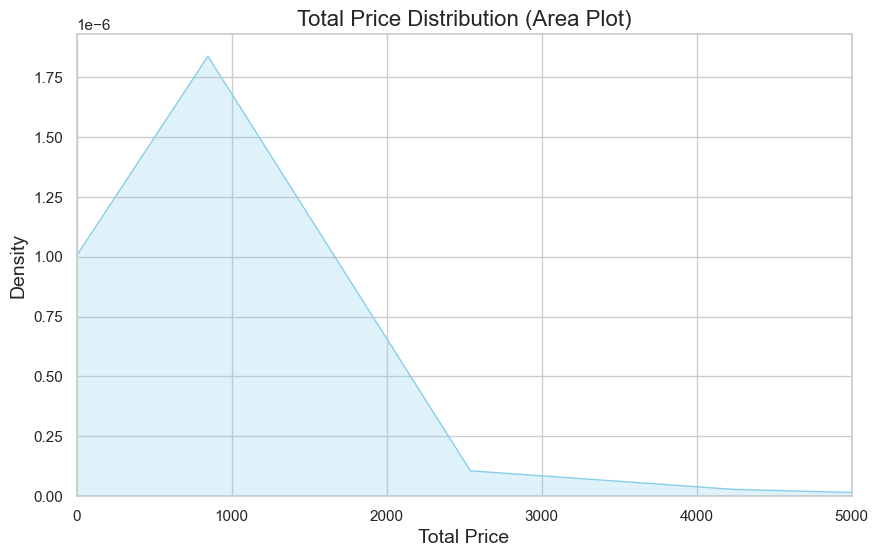

```python
# Set the style for Seaborn (optional but adds nice styling)
sns.set(style="whitegrid")

# Create the area plot
plt.figure(figsize=(10, 6))  # Adjust the figure size
sns.kdeplot(df['TotalPrice'], fill=True, color='skyblue')

# Labeling and title
plt.xlabel('Total Price', fontsize=14)
plt.ylabel('Density', fontsize=14)
plt.title('Total Price Distribution (Area Plot)', fontsize=16)

# Set x-axis limit
plt.xlim(-1, 5000)

# Show the plot
plt.show()
```

## 3. Data Aggregation:

3.1. Compute the total sales (TotalPrice) per country.

```python
sales_per_country = df.groupby('Country').sum()['TotalPrice']
print(sales_per_country)
```

```
Country
Australia                137077.270
Austria                   10154.320
Bahrain                     548.400
Belgium                   40910.960
Brazil                     1143.600
Canada                     3666.380
Channel Islands           20086.290
Cyprus                    12946.290
Czech Republic              707.720
Denmark                   18768.140
EIRE                     263276.820
European Community         1291.750
Finland                   22326.740
France                   197403.900
Germany                  221698.210
Greece                     4710.520
Hong Kong                 10117.040
Iceland                    4310.000
Israel                     7907.820
Italy                     16890.510
Japan                     35340.620
Lebanon                    1693.880
Lithuania                  1661.060
Malta                      2505.470
Netherlands              284661.540
Norway                    35163.460
Poland                     7213.140
Portugal                  29367.020
RSA                        1002.310
Saudi Arabia                131.170
Singapore                  9120.390
Spain                     54774.580
Sweden                    36595.910
Switzerland               56385.350
USA                        1730.920
United Arab Emirates       1902.280
United Kingdom          8187806.364
Unspecified                4749.790
Name: TotalPrice, dtype: float64
```

3.2. Identify the month in which the sales were highest.

```python
df['Month'] = df['InvoiceDate'].dt.month
month_sales = df.groupby('Month').sum()['TotalPrice']
top_month = month_sales.idxmax()
print(top_month)
```

```
11
```

3.3. Compute the average unit price per product.

```python
avg_price_per_product = df.groupby('StockCode').mean()['UnitPrice']
print(avg_price_per_product)
```

```
StockCode
10002            1.056849
10080            0.376667
10120            0.210000
10123C           0.487500
10123G           0.000000
                  ...
gift_0001_20    15.038000
gift_0001_30    21.941250
gift_0001_40    33.566667
gift_0001_50    41.890000
m                2.550000
Name: UnitPrice, Length: 4070, dtype: float64
```

```python
# Group the data by 'CustomerID' and calculate the sum of 'TotalPrice' for each customer.
top_customer = df.groupby('CustomerID')['TotalPrice'].sum()

# Get the corresponding 'Country' for each customer.
customer_countries = df.groupby('CustomerID')['Country'].first()

# Create a DataFrame to store the results.
result_df = pd.DataFrame({'TotalPrice': top_customer, 'Country': customer_countries})

# Sort the DataFrame in descending order based on 'TotalPrice'.
result_df = result_df.sort_values(by='TotalPrice', ascending=False)

# Print the result.
print(result_df.head(10))
```

```
            TotalPrice         Country
CustomerID
14646.0      279489.02     Netherlands
18102.0      256438.49  United Kingdom
17450.0      187482.17  United Kingdom
14911.0      132572.62            EIRE
12415.0      123725.45       Australia
14156.0      113384.14            EIRE
17511.0       88125.38  United Kingdom
16684.0       65892.08  United Kingdom
13694.0       62653.10  United Kingdom
15311.0       59419.34  United Kingdom
```

## 4. Data Visualization:

```python
!pip install flags
```

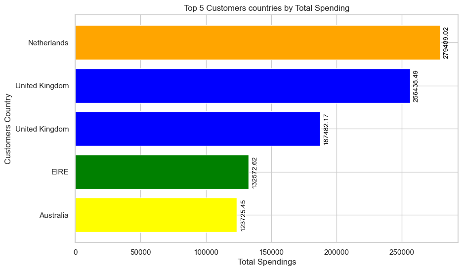

```python
# Sort the DataFrame in descending order based on 'TotalPrice' (optional, but useful for consistency in visualization).
result_df = result_df.sort_values(by='TotalPrice', ascending=False)

# Select the top 5 customers for visualization.
top_5_customers = result_df.head(5)

# Reverse the order of the top 5 customers to have the 1st customer at the top.
top_5_customers = top_5_customers.iloc[::-1]

# Create a bar chart.
fig, ax = plt.subplots(figsize=(10, 6))  # Adjust the figure size as needed

# Use a numerical range for the y-axis positions to ensure distinct bars.
y_positions = np.arange(len(top_5_customers))

# Define colors based on flag colors.
# Replace these with the actual colors corresponding to the countries.
flag_colors = ['yellow', 'green', 'blue', 'blue', 'orange']

bars = ax.barh(y_positions, top_5_customers['TotalPrice'], color=flag_colors)
ax.set_yticks(y_positions)
ax.set_yticklabels(top_5_customers['Country'])  # Replace numeric y-axis labels with country names
ax.set_xlabel('Total Spendings')
ax.set_ylabel('Customers Country')
ax.set_title('Top 5 Customers countries by Total Spending')

# Annotate the bars with the 'TotalPrice' values.
for bar, price in zip(bars, top_5_customers['TotalPrice']):
    ax.text(bar.get_width() + 5000, bar.get_y() + bar.get_height()/2, f'{price:.2f}', ha='center', va='center', fontsize=10, color='black', rotation=90)

# Display the plot.
plt.show()
```

4.1. Create a bar chart showcasing the sales (TotalPrice) for each country.

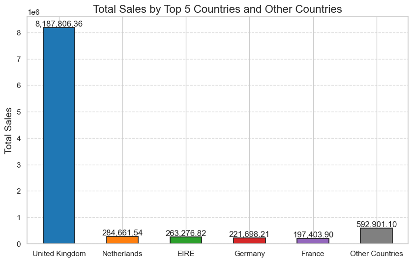

```python
# Sort the data by total sales in descending order and select the top 5 countries
top_countries = sales_per_country.sort_values(ascending=False).head(5)

# Calculate the sum of sales for all other countries
other_sales = sales_per_country.sort_values(ascending=False).iloc[5:].sum()

# Create a new DataFrame for the top 5 countries and 'Other Countries'
top_countries = top_countries.append(pd.Series(other_sales, index=['Other Countries']))

# Plot the data
import matplotlib.pyplot as plt

# Define a color palette
colors = ['#1f77b4', '#ff7f0e', '#2ca02c', '#d62728', '#9467bd', 'gray']

# Create the bar plot
plt.figure(figsize=(10, 6))
ax = top_countries.plot(kind='bar', color=colors, edgecolor='k', linewidth=1.2)

# Add labels and title
plt.ylabel('Total Sales', fontsize=14)
plt.title('Total Sales by Top 5 Countries and Other Countries', fontsize=16)

# Customize the x-axis labels for better readability
plt.xticks(rotation=0, ha='center')

# Add a grid for better visualization
plt.grid(axis='y', linestyle='--', alpha=0.7)

# Add data labels on top of the bars
for p in ax.patches:
    ax.annotate(f'{p.get_height():,.2f}', (p.get_x() + p.get_width() / 2., p.get_height()), ha='center', va='bottom', fontsize=12)

# Show the plot
plt.show()
```

4.2. Plot a line graph to showcase the trend of sales over time.

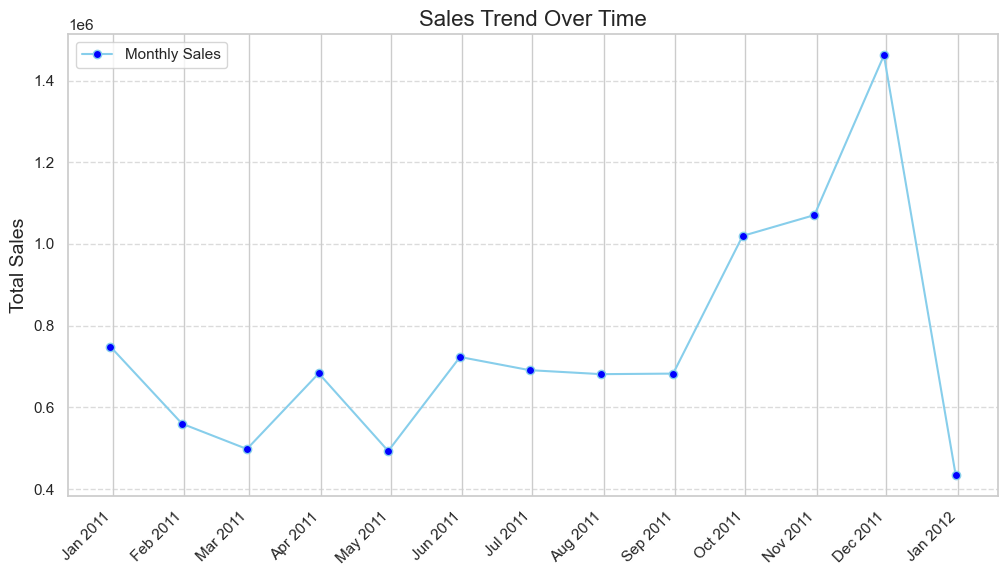

```python
import matplotlib.dates as mdates

# Convert 'InvoiceDate' to a datetime type
df['InvoiceDate'] = pd.to_datetime(df['InvoiceDate'])

# Set the style for Seaborn (optional but adds nice styling)
sns.set(style="whitegrid")

# Resample the data by month and sum the TotalPrice
monthly_sales = df.resample('M', on='InvoiceDate').sum()

# Create the figure and axis objects
fig, ax = plt.subplots(figsize=(12, 6))

# Plot the data
ax.plot(monthly_sales.index, monthly_sales['TotalPrice'], color='skyblue', marker='o', markersize=6, markerfacecolor='blue', label='Monthly Sales')

# Beautify the x-axis by formatting the date labels
ax.xaxis.set_major_locator(mdates.MonthLocator(interval=1))
ax.xaxis.set_major_formatter(mdates.DateFormatter("%b %Y"))

# Labeling and title
plt.ylabel('Total Sales', fontsize=14)
plt.title('Sales Trend Over Time', fontsize=16)

# Add a grid for better visualization
plt.grid(axis='y', linestyle='--', alpha=0.7)

# Rotate the x-axis labels for better readability
plt.xticks(rotation=45, ha='right')

# Show a legend
plt.legend(loc='upper left')

# Show the plot
plt.show()
```

4.3. Use a scatter plot to visualize the relationship between UnitPrice and Quantity.

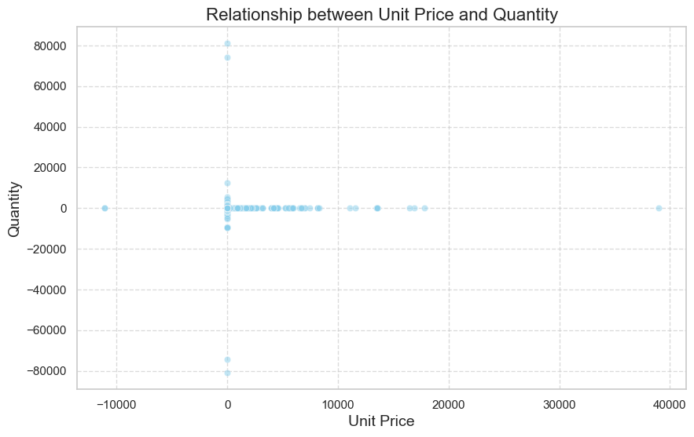

```python
# Set the style for Seaborn (optional but adds nice styling)
sns.set(style="whitegrid")

# Create the scatter plot
plt.figure(figsize=(10, 6))
sns.scatterplot(x='UnitPrice', y='Quantity', data=df, alpha=0.5, color='skyblue')

# Labeling and title
plt.xlabel('Unit Price', fontsize=14)
plt.ylabel('Quantity', fontsize=14)
plt.title('Relationship between Unit Price and Quantity', fontsize=16)

# Add grid lines
plt.grid(linestyle='--', alpha=0.7)

# Show the plot
plt.show()
```

4.4. Plot a heatmap to display the correlation between numeric columns.

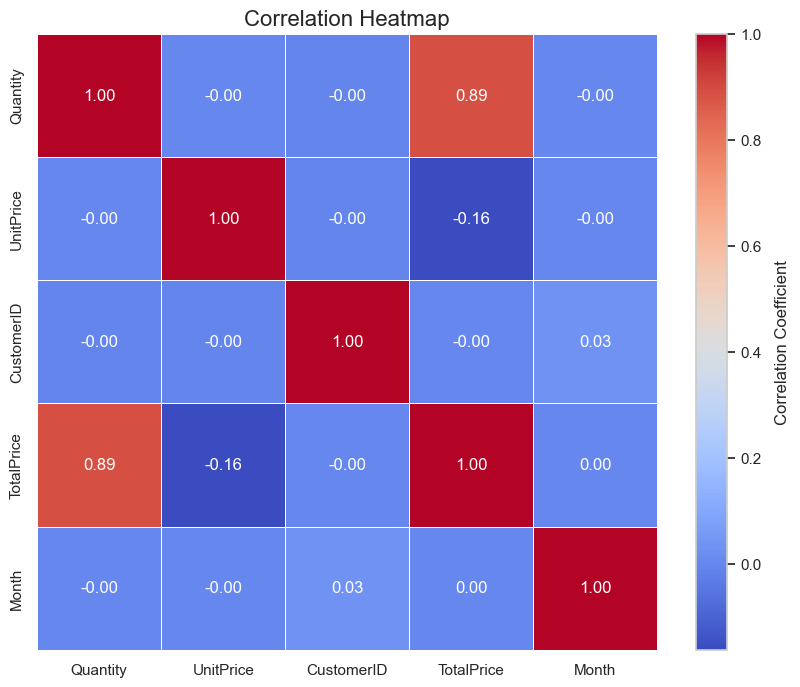

```python
# Compute the correlation matrix
correlation_matrix = df.corr()

# Set the style for Seaborn (optional but adds nice styling)
sns.set(style="whitegrid")

# Create the heatmap
plt.figure(figsize=(10, 8))
ax = sns.heatmap(correlation_matrix, annot=True, cmap='coolwarm', fmt=".2f", linewidths=0.5)

# Set a more descriptive title
plt.title('Correlation Heatmap', fontsize=16)

# Remove the existing color bar
ax.collections[0].colorbar.remove()

# Add a new color bar to the right of the heatmap
cbar = plt.colorbar(ax.collections[0])
cbar.set_label('Correlation Coefficient', labelpad=10, fontsize=12)

# Show the plot
plt.show()
```

## 5. Advanced Analysis:

5.1. Identify potential outliers in the dataset for the Quantity and UnitPrice columns using appropriate visualization techniques.

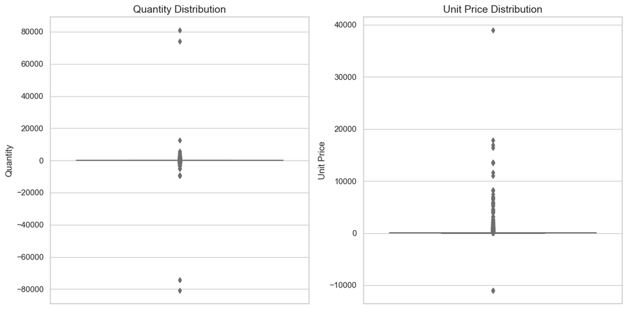

```python
# Set the style for Seaborn (optional but adds nice styling)
sns.set(style="whitegrid")

# Create a single figure with two subplots side by side
fig, axes = plt.subplots(1, 2, figsize=(12, 6))

# Plot the box plot for 'Quantity'
sns.boxplot(y=df['Quantity'], ax=axes[0], color='skyblue')
axes[0].set_title('Quantity Distribution', fontsize=14)
axes[0].set_ylabel('Quantity', fontsize=12)

# Plot the box plot for 'UnitPrice'
sns.boxplot(y=df['UnitPrice'], ax=axes[1], color='lightcoral')
axes[1].set_title('Unit Price Distribution', fontsize=14)
axes[1].set_ylabel('Unit Price', fontsize=12)

# Set spacing between the subplots
plt.tight_layout()

# Show the plot
plt.show()
```

5.2. Segment customers based on their purchase history (Consider factors like total purchases, frequency of purchases, etc.).

```python
df['TotalSpent'] = df['Quantity'] * df['UnitPrice']
customer_segment = df.groupby('CustomerID').agg({'TotalSpent': 'sum', 'InvoiceNo': 'nunique'})
customer_segment.rename(columns={'InvoiceNo': 'NumPurchases'}, inplace=True)
print(customer_segment)
```

```
            TotalSpent  NumPurchases
CustomerID
12346.0           0.00             2
12347.0        4310.00             7
12348.0        1797.24             4
12349.0        1757.55             1
12350.0         334.40             1
...                ...           ...
18280.0         180.60             1
18281.0          80.82             1
18282.0         176.60             3
18283.0        2094.88            16
18287.0        1837.28             3

[4372 rows x 2 columns]
```

5.3. For the top 5 products (by quantity sold), visualize their monthly sales trend.

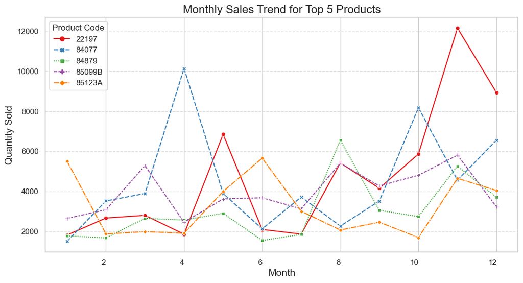

```python
# Compute the top 5 products by total quantity sold
top_5_products = df.groupby('StockCode').sum().nlargest(5, 'Quantity').index

# Filter the data to include only the top 5 products
filtered_df = df[df['StockCode'].isin(top_5_products)]

# Group the data by month and product code and calculate the total quantity sold
pivot_data = filtered_df.groupby(['Month', 'StockCode']).sum()['Quantity'].unstack()

# Set the style for Seaborn (optional but adds nice styling)
sns.set(style="whitegrid")

# Create the line plot
plt.figure(figsize=(12, 6))
sns.lineplot(data=pivot_data, markers=True, palette='Set1')

# Labeling and title
plt.xlabel('Month', fontsize=14)
plt.ylabel('Quantity Sold', fontsize=14)
plt.title('Monthly Sales Trend for Top 5 Products', fontsize=16)

# Add a legend
plt.legend(title='Product Code', title_fontsize=12)

# Customize the x-axis labels for better readability
plt.xticks(ha='right')

# Add grid lines
plt.grid(axis='y', linestyle='--', alpha=0.7)

# Show the plot
plt.show()
```

```python
# Group the data by 'StockCode' and calculate the sum of 'Quantity' and 'TotalPrice' for each stock code.
top_stock_codes = df.groupby('StockCode').agg({'Quantity': 'sum', 'UnitPrice': 'first'}).reset_index()

# Sort the DataFrame in descending order based on 'Quantity' and select the top 10.
top_stock_codes = top_stock_codes.sort_values(by='Quantity', ascending=False).head(10)

# Print the top 10 stock codes with descriptions and total prices.
print(top_stock_codes[['StockCode', 'Quantity', 'UnitPrice']])
```

```
     StockCode  Quantity  UnitPrice
1147     22197     56450       0.72
2997     84077     53847       0.29
3515    85099B     47363       1.65
3536    85123A     38830       2.55
3305     84879     36221       1.69
454      21212     36039       0.42
1982     23084     30646       2.08
1412     22492     26437       0.65
1530     22616     26315       0.29
966      21977     24753       0.55
```

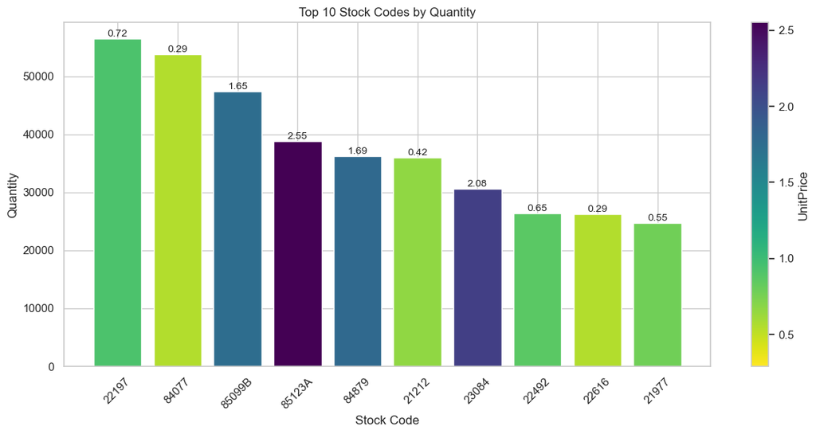

```python
# Sort the DataFrame in descending order based on 'Quantity'.
top_stock_codes = top_stock_codes.sort_values(by='Quantity', ascending=False)

# Create a bar chart for the top 10 StockCodes.
plt.figure(figsize=(12, 6))  # Adjust the figure size as needed

# Use a numerical range for the x-axis positions to ensure distinct bars.
x_positions = range(len(top_stock_codes))

# Create a colormap based on UnitPrice.
colors = plt.cm.viridis_r(top_stock_codes['UnitPrice'] / top_stock_codes['UnitPrice'].max())

bars = plt.bar(x_positions, top_stock_codes['Quantity'], align='center', color=colors)
plt.xticks(x_positions, top_stock_codes['StockCode'], rotation=45)
plt.xlabel('Stock Code')
plt.ylabel('Quantity')
plt.title('Top 10 Stock Codes by Quantity')

# Annotate the bars with numeric labels (UnitPrice).
for x, quantity, unit_price in zip(x_positions, top_stock_codes['Quantity'], top_stock_codes['UnitPrice']):
    plt.text(x, quantity + 10, f'{unit_price:.2f}', ha='center', va='bottom', fontsize=10)

plt.tight_layout()

# Create a colorbar to indicate UnitPrice.
sm = plt.cm.ScalarMappable(cmap=plt.cm.viridis_r, norm=plt.Normalize(vmin=top_stock_codes['UnitPrice'].min(), vmax=top_stock_codes['UnitPrice'].max()))
sm.set_array([])

cbar = plt.colorbar(sm)
cbar.set_label('UnitPrice')

plt.show()
```

```python
# Group the data by 'StockCode' and calculate the sum of 'TotalPrice', the mean of 'UnitPrice', and the sum of 'Quantity' for each stock code.
top_stock_codes_TP = df.groupby('StockCode').agg({'TotalPrice': 'sum', 'UnitPrice': 'mean', 'Quantity': 'sum'}).reset_index()

# Sort the DataFrame in descending order based on 'TotalPrice' and select the top 10.
top_stock_codes_TP = top_stock_codes_TP.sort_values(by='TotalPrice', ascending=False).head(10)

# Print the top 10 stock codes based on TotalPrice, including UnitPrice and Quantity.
print(top_stock_codes_TP)
```

```
     StockCode  TotalPrice   UnitPrice  Quantity
4059       DOT   206245.48  290.495859      1707
1348     22423   164762.19   13.781484     12980
2733     47566    98302.98    5.778587     18022
3536    85123A    97894.50    3.103238     38830
3515    85099B    92356.03    2.470264     47363
1982     23084    66756.59    2.339766     30646
4062      POST    66230.64   36.933495      6353
1043     22086    63791.94    3.351157     18902
3305     84879    58959.73    1.720885     36221
2924     79321    53768.06    6.705242     10343
```

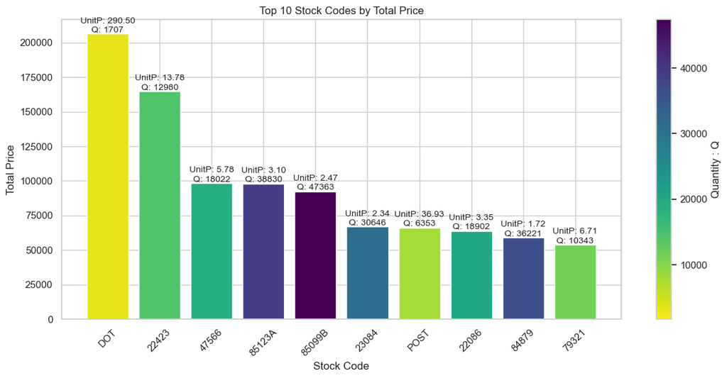

```python
from matplotlib.cm import ScalarMappable

# Sort the DataFrame in descending order based on 'TotalPrice'.
top_stock_codes_TP = top_stock_codes_TP.sort_values(by='TotalPrice', ascending=False)

plt.figure(figsize=(12, 6))  # Adjust the figure size as needed

# Use a numerical range for the x-axis positions to ensure distinct bars.
x_positions = range(len(top_stock_codes_TP))

# Create a colormap based on Quantity, reversing the colors with 'viridis_r'.
colors = plt.cm.viridis_r(top_stock_codes_TP['Quantity'] / top_stock_codes_TP['Quantity'].max())

bars = plt.bar(x_positions, top_stock_codes_TP['TotalPrice'], color=colors, label='TotalPrice')
plt.xticks(x_positions, top_stock_codes_TP['StockCode'], rotation=45)
plt.xlabel('Stock Code')
plt.ylabel('Total Price')
plt.title('Top 10 Stock Codes by Total Price')

# Annotate the bars with UnitPrice and Quantity.
for x, total_price, unit_price, quantity in zip(x_positions, top_stock_codes_TP['TotalPrice'], top_stock_codes_TP['UnitPrice'], top_stock_codes_TP['Quantity']):
    plt.text(x, total_price + 10, f'UnitP: {unit_price:.2f}\n Q: {quantity} ', ha='center', va='bottom', fontsize=10)

# Create a colorbar to indicate Quantity.
sm = ScalarMappable(cmap=plt.cm.viridis_r, norm=plt.Normalize(vmin=top_stock_codes_TP['Quantity'].min(), vmax=top_stock_codes_TP['Quantity'].max()))
sm.set_array([])

cbar = plt.colorbar(sm)
cbar.set_label('Quantity : Q')

plt.tight_layout()
plt.show()
```

# Advanced Machine Learning Analysis with Retail Dataset

## 6. Feature Engineering:

6.1 Extract 'Year', 'Month', 'Day', and 'Hour' from the InvoiceDate and create separate columns for each.

```python
df.reset_index(inplace=True)
df['Year'] = df['InvoiceDate'].dt.year
df['Month'] = df['InvoiceDate'].dt.month
df['Day'] = df['InvoiceDate'].dt.day
df['Hour'] = df['InvoiceDate'].dt.hour
df.head()
```

|  | index | InvoiceNo | StockCode | Description | Quantity | InvoiceDate | UnitPrice | CustomerID | Country | TotalPrice | Month | TotalSpent | Year | Day | Hour |
| --- | --- | --- | --- | --- | --- | --- | --- | --- | --- | --- | --- | --- | --- | --- | --- |
| 0 | 0 | 536365 | 85123A | WHITE HANGING HEART T-LIGHT HOLDER | 6 | 2010-12-01 08:26:00 | 2.55 | 17850.0 | United Kingdom | 15.30 | 12 | 15.30 | 2010 | 1 | 8 |
| 1 | 1 | 536365 | 71053 | WHITE METAL LANTERN | 6 | 2010-12-01 08:26:00 | 3.39 | 17850.0 | United Kingdom | 20.34 | 12 | 20.34 | 2010 | 1 | 8 |
| 2 | 2 | 536365 | 84406B | CREAM CUPID HEARTS COAT HANGER | 8 | 2010-12-01 08:26:00 | 2.75 | 17850.0 | United Kingdom | 22.00 | 12 | 22.00 | 2010 | 1 | 8 |
| 3 | 3 | 536365 | 84029G | KNITTED UNION FLAG HOT WATER BOTTLE | 6 | 2010-12-01 08:26:00 | 3.39 | 17850.0 | United Kingdom | 20.34 | 12 | 20.34 | 2010 | 1 | 8 |
| 4 | 4 | 536365 | 84029E | RED WOOLLY HOTTIE WHITE HEART. | 6 | 2010-12-01 08:26:00 | 3.39 | 17850.0 | United Kingdom | 20.34 | 12 | 20.34 | 2010 | 1 | 8 |

6.2 Create a new column `'ReturnFlag'` where if `'Quantity'` is less than zero, it's 1, otherwise 0. This will indicate whether an item was returned.

```python
df['ReturnFlag'] = df['Quantity'].apply(lambda x: 1 if x < 0 else 0)
df.head()
```

|  | index | InvoiceNo | StockCode | Description | Quantity | InvoiceDate | UnitPrice | CustomerID | Country | TotalPrice | Month | TotalSpent | Year | Day | Hour | ReturnFlag |
| --- | --- | --- | --- | --- | --- | --- | --- | --- | --- | --- | --- | --- | --- | --- | --- | --- |
| 0 | 0 | 536365 | 85123A | WHITE HANGING HEART T-LIGHT HOLDER | 6 | 2010-12-01 08:26:00 | 2.55 | 17850.0 | United Kingdom | 15.30 | 12 | 15.30 | 2010 | 1 | 8 | 0 |
| 1 | 1 | 536365 | 71053 | WHITE METAL LANTERN | 6 | 2010-12-01 08:26:00 | 3.39 | 17850.0 | United Kingdom | 20.34 | 12 | 20.34 | 2010 | 1 | 8 | 0 |
| 2 | 2 | 536365 | 84406B | CREAM CUPID HEARTS COAT HANGER | 8 | 2010-12-01 08:26:00 | 2.75 | 17850.0 | United Kingdom | 22.00 | 12 | 22.00 | 2010 | 1 | 8 | 0 |
| 3 | 3 | 536365 | 84029G | KNITTED UNION FLAG HOT WATER BOTTLE | 6 | 2010-12-01 08:26:00 | 3.39 | 17850.0 | United Kingdom | 20.34 | 12 | 20.34 | 2010 | 1 | 8 | 0 |
| 4 | 4 | 536365 | 84029E | RED WOOLLY HOTTIE WHITE HEART. | 6 | 2010-12-01 08:26:00 | 3.39 | 17850.0 | United Kingdom | 20.34 | 12 | 20.34 | 2010 | 1 | 8 | 0 |

## 7. Customer Segmentation using Clustering:

7.1. Create a matrix RFM (Recency, Frequency, Monetary) for each customer:

- Recency: Number of days since the last purchase
- Frequency: Number of purchases
- Monetary: Total money spent

```python
# Calculate Recency, Frequency and Monetary for each customer
current_date = df['InvoiceDate'].max()

rfm = df.groupby('CustomerID').agg({
    'InvoiceDate': lambda x: (current_date - x.max()).days,  # Recency
    'InvoiceNo': 'count',                                   # Frequency
    'TotalPrice': 'sum'                                      # Monetary
}).rename(columns={
    'InvoiceDate': 'Recency',
    'InvoiceNo': 'Frequency',
    'TotalPrice': 'Monetary'
})

rfm.head()
```

| CustomerID | Recency | Frequency | Monetary |
| --- | --- | --- | --- |
| 12346.0 | 325 | 2 | 0.00 |
| 12347.0 | 1 | 182 | 4310.00 |
| 12348.0 | 74 | 31 | 1797.24 |
| 12349.0 | 18 | 73 | 1757.55 |
| 12350.0 | 309 | 17 | 334.40 |

```python
# Calculate Recency, Frequency, and Monetary for each customer as shown in your previous code
current_date = df['InvoiceDate'].max()

rfm = df.groupby('CustomerID').agg({
    'InvoiceDate': lambda x: (current_date - x.max()).days,  # Recency
    'InvoiceNo': 'count',                                   # Frequency
    'TotalPrice': 'sum'                                      # Monetary
}).rename(columns={
    'InvoiceDate': 'Recency',
    'InvoiceNo': 'Frequency',
    'TotalPrice': 'Monetary'
})

# Define weights for each RFM component (you can adjust these weights)
weight_recency = 0.2
weight_frequency = 0.3
weight_monetary = 0.5

# Calculate a composite RFM score for each customer
rfm['RFM_Score'] = (rfm['Recency'] * weight_recency +
                   rfm['Frequency'] * weight_frequency +
                   rfm['Monetary'] * weight_monetary)

# Sort customers by their RFM score in descending order and select the top 10 customers.
top_10_customers_rmf = rfm.sort_values(by='RFM_Score', ascending=False).head(10)

# Print the top 10 customers based on RMF.
print("Top 10 Customers based on RMF:")
print(top_10_customers_rmf)
```

```
Top 10 Customers based on RMF:
            Recency  Frequency   Monetary   RFM_Score
CustomerID
14646.0           1       2085  279489.02  140370.210
18102.0           0        433  256438.49  128349.145
17450.0           7        351  187482.17   93847.785
14911.0           0       5903  132572.62   68057.210
12415.0          23        778  123725.45   62100.725
14156.0           9       1420  113384.14   57119.870
17511.0           2       1076   88125.38   44385.890
16684.0           3        281   65892.08   33030.940
13694.0           3        585   62653.10   31502.650
15311.0           0       2491   59419.34   30456.970
```

```python
customer_country = df[['CustomerID', 'Country']].drop_duplicates()

# You can use the 'drop_duplicates()' method to ensure that each 'CustomerID' is unique in the new DataFrame.

# Now, if you want to save this mapping to a new CSV file, you can do the following:
customer_country.to_csv('customer_country_mapping.csv', index=False)
```

```python
# Join the 'rfm' DataFrame with 'customer_info' to include the 'Country' column.
rfm_with_country = rfm.join(customer_country.set_index('CustomerID')['Country'])

# Sort the 'rfm_with_country' DataFrame by 'RMF_Score'.
rfm_with_country = rfm_with_country.sort_values(by='RFM_Score')

# Print the top and bottom 10 customers along with their countries.
print("Top 10 Customers based on RMF:")
print(rfm_with_country.head(10), '\n')

print("Bottom 10 Customers based on RMF:")
print(rfm_with_country.tail(10))
```

[output not shown]

```python
# Sort the RFM DataFrame by Recency in ascending order and select the top 5 customers.
top_5_recency = rfm.sort_values(by='Recency').head(5)

# Sort the RFM DataFrame by Frequency in descending order and select the top 5 customers.
top_5_frequency = rfm_with_country.sort_values(by='Frequency', ascending=False).head(5)

# Sort the RFM DataFrame by Monetary in descending order and select the top 5 customers.
top_5_monetary = rfm.sort_values(by='Monetary', ascending=False).head(5)

# Print the top 5 customers for each metric.
print("Top 5 Customers for Recency:")
print(top_5_recency)

print("\nTop 5 Customers for Frequency:")
print(top_5_frequency)

print("\nTop 5 Customers for Monetary:")
print(top_5_monetary)
```

```
Top 5 Customers for Recency:
            Recency  Frequency  Monetary  RFM_Score
CustomerID
17491.0           0        110   3541.92   1803.960
16933.0           0         49    530.08    279.740
16558.0           0        474   8257.04   4270.720
13026.0           0         43    936.15    480.975
17364.0           0        414   4455.73   2352.065

Top 5 Customers for Frequency:
            Recency  Frequency   Monetary  RFM_Score         Country
CustomerID
17841.0           1       7983   40340.78  22565.490  United Kingdom
14911.0           0       5903  132572.62  68057.210            EIRE
14096.0           3       5128   57120.91  30099.455  United Kingdom
12748.0           0       4642   29072.10  15928.650  United Kingdom
14606.0           0       2782   11713.85   6691.525  United Kingdom

Top 5 Customers for Monetary:
            Recency  Frequency   Monetary   RFM_Score
CustomerID
14646.0           1       2085  279489.02  140370.210
18102.0           0        433  256438.49  128349.145
17450.0           7        351  187482.17   93847.785
14911.0           0       5903  132572.62   68057.210
12415.0          23        778  123725.45   62100.725
```

```python
rfm_with_country.head()
```

| CustomerID | Recency | Frequency | Monetary | RFM_Score | Country |
| --- | --- | --- | --- | --- | --- |
| 17448.0 | 144 | 1 | -4287.63 | -2114.715 | United Kingdom |
| 15369.0 | 143 | 1 | -1592.49 | -767.345 | United Kingdom |
| 17603.0 | 49 | 15 | -1165.30 | -568.350 | United Kingdom |
| 14213.0 | 371 | 5 | -1192.20 | -520.400 | United Kingdom |
| 12503.0 | 337 | 1 | -1126.00 | -495.300 | Spain |

7.2. Normalize the RFM matrix:

```python
from sklearn.preprocessing import StandardScaler

scaler = StandardScaler()
rfm_normalized = scaler.fit_transform(rfm)
rfm_normalized
```

```
array([[ 2.32202285, -0.3917197 , -0.23100099, -0.22467867],
       [-0.89373323,  0.38265697,  0.29343167,  0.29347489],
       [-0.1691956 , -0.26695902, -0.01231622, -0.01755257],
       ...,
       [-0.83418219, -0.34439668, -0.20951263, -0.21791237],
       [-0.87388289,  2.85205812,  0.02390005,  0.06753848],
       [-0.48680114, -0.0991774 , -0.00744423, -0.0114339 ]])
```

7.3. Use K-Means clustering to segment customers into different groups. Determine the optimal number of clusters using the Elbow method.

```python
!pip install -U threadpoolctl
```

```python
!pip install --upgrade scikit-learn
```

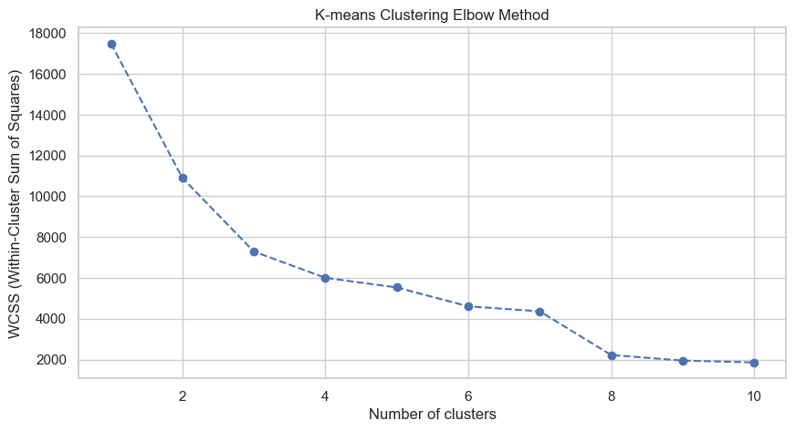

```python
import matplotlib.pyplot as plt
from sklearn.cluster import KMeans

# Determine the optimal number of clusters using the Elbow method
def find_optimal_clusters(data, max_clusters=10):
    wcss = []
    for i in range(1, max_clusters + 1):
        kmeans = KMeans(n_clusters=i, init='random', random_state=42)
        kmeans.fit(data)
        wcss.append(kmeans.inertia_)

    return wcss

# Plot the Elbow method
def plot_elbow(wcss_values, max_clusters):
    plt.figure(figsize=(10, 5))
    plt.plot(range(1, max_clusters + 1), wcss_values, marker='o', linestyle='--')
    plt.xlabel('Number of clusters')
    plt.ylabel('WCSS (Within-Cluster Sum of Squares)')
    plt.title('K-means Clustering Elbow Method')
    plt.show()

# Perform K-means clustering with the optimal number of clusters
def perform_kmeans(data, n_clusters):
    kmeans = KMeans(n_clusters=n_clusters, init='random', random_state=42)
    clusters = kmeans.fit_predict(data)
    return clusters

# Find the optimal number of clusters
wcss_values = find_optimal_clusters(rfm_normalized, max_clusters=10)
plot_elbow(wcss_values, max_clusters=10)

# Based on the elbow point, choose the optimal number of clusters and run K-means
optimal_clusters = 3  # Adjust this based on the elbow plot
clusters = perform_kmeans(rfm_normalized, optimal_clusters)
rfm['Cluster'] = clusters
```

[figure not shown]

```python
# Determine the counts of customers in each cluster
cluster_counts = rfm['Cluster'].value_counts()

# Define colors for each cluster
colors = ['lightcoral', 'lightgreen', 'skyblue']

# Create a pie chart
plt.figure(figsize=(8, 6))
plt.title('Customer Segmentation')
plt.pie(cluster_counts, labels=cluster_counts.index, autopct='%1.1f%%', startangle=90, colors=colors)

# Add a legend outside the pie chart
legend_labels = ['High-Value Customers', 'Mid-Value Customers', 'Low-Value Customers']
plt.legend(legend_labels, loc="upper left", bbox_to_anchor=(1, 1))

# Equal aspect ratio ensures that the pie chart is drawn as a circle.
plt.axis('equal')
plt.show()

# Segment the customers based on the clusters
# You can change the threshold values based on your analysis and business understanding
high_value_customers = rfm[rfm['Cluster'] == 0]  # Assuming 0 is the cluster number for high-value customers
mid_value_customers = rfm[rfm['Cluster'] == 1]  # Assuming 1 is the cluster number for mid-value customers
low_value_customers = rfm[rfm['Cluster'] == 2]  # Assuming 2 is the cluster number for low-value customers
```

## 8. Predictive Analytics:

8.1. Can you predict if a customer will return an item? Use the 'ReturnFlag' as the target variable and build a classification model.

- Split data into training and test sets.
- Use features like 'UnitPrice', 'Quantity', etc.
- Evaluate model accuracy, precision, recall, and F1-score.

```python
df.info()
```

```
<class 'pandas.core.frame.DataFrame'>
RangeIndex: 541909 entries, 0 to 541908
Data columns (total 16 columns):
 #   Column       Non-Null Count   Dtype
---  ------       --------------   -----
 0   index        541909 non-null  int64
 1   InvoiceNo    541909 non-null  object
 2   StockCode    541909 non-null  object
 3   Description  540455 non-null  object
 4   Quantity     541909 non-null  int64
 5   InvoiceDate  541909 non-null  datetime64[ns]
 6   UnitPrice    541909 non-null  float64
 7   CustomerID   406829 non-null  float64
 8   Country      541909 non-null  object
 9   TotalPrice   541909 non-null  float64
 10  Month        541909 non-null  int64
 11  TotalSpent   541909 non-null  float64
 12  Year         541909 non-null  int64
 13  Day          541909 non-null  int64
 14  Hour         541909 non-null  int64
 15  ReturnFlag   541909 non-null  int64
dtypes: datetime64[ns](1), float64(4), int64(7), object(4)
memory usage: 66.2+ MB
```

```python
from sklearn.model_selection import train_test_split
from sklearn.ensemble import RandomForestClassifier
from sklearn.metrics import classification_report

features = df[['UnitPrice', 'Quantity']]  # you can add more features
target = df['ReturnFlag']

for col in ['InvoiceDate', 'InvoiceNo','StockCode', 'Description', 'Country', 'CustomerID']:
    if col in features.columns:
        del features[col]

X_train, X_test, y_train, y_test = train_test_split(features, target, test_size=0.2, random_state=42)

clf = RandomForestClassifier(random_state=42)
clf.fit(X_train, y_train)

predictions = clf.predict(X_test)

print(classification_report(y_test, predictions))
```

```
              precision    recall  f1-score   support

           0       1.00      1.00      1.00    106226
           1       1.00      1.00      1.00      2156

    accuracy                           1.00    108382
   macro avg       1.00      1.00      1.00    108382
weighted avg       1.00      1.00      1.00    108382
```

8.2. Predict the `'TotalPrice'` for an invoice using regression models.

```python
from sklearn.linear_model import LinearRegression
from sklearn.metrics import mean_squared_error, r2_score

# Assuming df has dummy variables for categorical columns
features = df.drop(columns=['TotalPrice'])
target = df['TotalPrice']
for col in ['InvoiceDate', 'InvoiceNo','StockCode', 'Description', 'Country', 'CustomerID']:
    if col in features.columns:
        del features[col]

X_train, X_test, y_train, y_test = train_test_split(features, target, test_size=0.2, random_state=42)
reg = LinearRegression()
reg.fit(X_train, y_train)

predictions = reg.predict(X_test)

print('RMSE:', mean_squared_error(y_test, predictions, squared=False))
print('R^2:', r2_score(y_test, predictions))
```

```
RMSE: 2.8127617505998157e-11
R^2: 1.0
```

## 9. Association Rule Mining:

- 9.1 Identify frequently bought products together. Use the Apriori algorithm to extract meaningful association rules.
- 9.2 Based on the rules, suggest product bundling strategies to the retail store.

```python
! pip install mlxtend --q
```

```python
from mlxtend.frequent_patterns import apriori, association_rules

# Creating a basket
basket = (df.groupby(['InvoiceNo', 'Description'])['Quantity']
          .sum().unstack().reset_index().fillna(0)
          .set_index('InvoiceNo'))

# Convert the units to 1 hot encoded values
def encode_units(x):
    if x <= 0:
        return 0
    if x >= 1:
        return 1

basket_encoded = basket.applymap(encode_units)

# Build frequent items
frequent_itemsets = apriori(basket_encoded, min_support=0.03, use_colnames=True)

# Association rules
rules = association_rules(frequent_itemsets, metric="lift", min_threshold=1)
rules
```

|  | antecedents | consequents | antecedent support | consequent support | support | confidence | lift | leverage | conviction | zhangs_metric |
| --- | --- | --- | --- | --- | --- | --- | --- | --- | --- | --- |
| 0 | (GREEN REGENCY TEACUP AND SAUCER) | (ROSES REGENCY TEACUP AND SAUCER ) | 0.041520 | 0.043606 | 0.031416 | 0.756650 | 17.351850 | 0.029606 | 3.930120 | 0.983191 |
| 1 | (ROSES REGENCY TEACUP AND SAUCER ) | (GREEN REGENCY TEACUP AND SAUCER) | 0.043606 | 0.041520 | 0.031416 | 0.720450 | 17.351850 | 0.029606 | 3.428656 | 0.985336 |
| 2 | (JUMBO BAG PINK POLKADOT) | (JUMBO BAG RED RETROSPOT) | 0.049824 | 0.085576 | 0.033748 | 0.677340 | 7.915034 | 0.029484 | 2.834015 | 0.919470 |
| 3 | (JUMBO BAG RED RETROSPOT) | (JUMBO BAG PINK POLKADOT) | 0.085576 | 0.049824 | 0.033748 | 0.394359 | 7.915034 | 0.029484 | 1.568878 | 0.955419 |

# Advanced EDA Techniques:

1. Pareto Analysis (80/20 Rule):
- Identify the 20% of the products that generate 80% of the revenue.
- Conversely, identify the 20% of the customers responsible for 80% of the sales.

```python
# For top products (80% revenue):
product_revenue = df.groupby('StockCode')['TotalPrice'].sum()
sorted_product_revenue = product_revenue.sort_values(ascending=False)
cumulative_product_revenue = sorted_product_revenue.cumsum()
total_revenue = cumulative_product_revenue.max()
threshold_revenue = 0.8 * total_revenue
top_products_80_percent = sorted_product_revenue[cumulative_product_revenue <= threshold_revenue]

# For top customers (80% sales):
customer_sales = df.groupby('CustomerID')['TotalPrice'].sum()
sorted_customer_sales = customer_sales.sort_values(ascending=False)
cumulative_customer_sales = sorted_customer_sales.cumsum()
total_sales = cumulative_customer_sales.max()
threshold_sales = 0.8 * total_sales
top_customers_80_percent = sorted_customer_sales[cumulative_customer_sales <= threshold_sales]

# Print top products and top customers
print("Top 20% of products generating 80% of revenue:")
print(top_products_80_percent)

print("Top 20% of customers responsible for 80% of sales:")
print(top_customers_80_percent)
```

```
Top 20% of products generating 80% of revenue:
StockCode
DOT       206245.48
22423     164762.19
47566      98302.98
85123A     97894.50
85099B     92356.03
            ...
23396       2765.53
21109       2765.15
22072       2759.92
23190       2758.60
22224       2755.21
Name: TotalPrice, Length: 823, dtype: float64
Top 20% of customers responsible for 80% of sales:
CustomerID
14646.0    279489.02
18102.0    256438.49
17450.0    187482.17
14911.0    132572.62
12415.0    123725.45
             ...
17002.0      1487.78
17553.0      1487.60
16395.0      1486.90
14878.0      1485.54
14414.0      1485.13
Name: TotalPrice, Length: 1177, dtype: float64
```

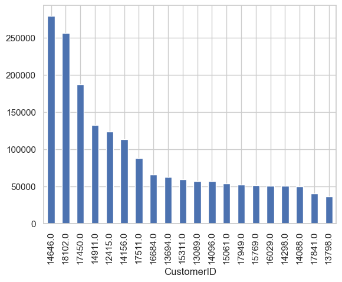

```python
top_20_percent_products = int(0.2 * len(df['StockCode'].unique()))
top_products = df.groupby('StockCode').sum().nlargest(top_20_percent_products, 'TotalPrice')
top_products['TotalPrice'].plot(kind='bar')

top_20_percent_customers = int(0.2 * len(df['CustomerID'].unique()))
top_customers = df.groupby('CustomerID').sum().nlargest(top_20_percent_customers, 'TotalPrice')
top_customers['TotalPrice'].head(20).plot(kind='bar')
```

1. Time-Series Anomalies:
- Detect any anomalies or outliers in the sales data over time using rolling averages or other advanced methods.

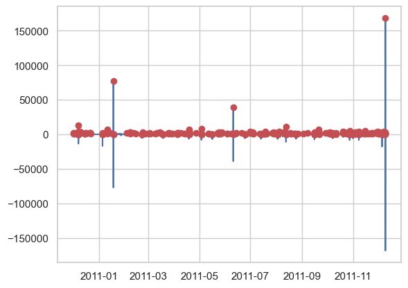

```python
df['RollingMean'] = df['TotalPrice'].rolling(window=5).mean()

anomalies = df[df['TotalPrice'] > df['RollingMean'] + 1.96*df['TotalPrice'].std()]
plt.plot(df['InvoiceDate'], df['TotalPrice'])
plt.plot(anomalies['InvoiceDate'], anomalies['TotalPrice'], 'ro')
```

# Advanced Modeling Techniques:

1. Market Basket Analysis Enhancements:
- Dig deeper into association rules. For instance, find rules with a high lift and high confidence.
- Analyze antecedents with more than one item, which can give bundled product suggestions.

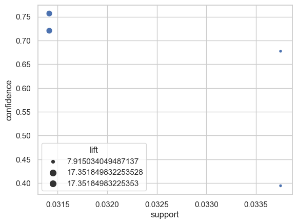

```python
rules = association_rules(frequent_itemsets, metric="lift", min_threshold=0.1)
top_rules = rules[rules['confidence'] > 0.01]
sns.scatterplot(x='support', y='confidence', size='lift', data=top_rules)
```

## 19. Product Recommendation Systems:

- Develop a system to recommend products to users.
- Consider collaborative filtering techniques, matrix factorization, or deep learning-based approaches like neural collaborative filtering.

```python
from sklearn.metrics.pairwise import cosine_similarity

# Create a user-product matrix
user_product_matrix = df.pivot_table(index='CustomerID', columns='StockCode', values='Quantity', fill_value=0)
reindexed_user_product_matrix = user_product_matrix.reset_index()
# Compute the cosine similarity matrix
cosine_sim = cosine_similarity(user_product_matrix)

# Get product recommendations for a user based on their purchase history
def get_recommendations(user_id, cosine_sim=cosine_sim):
    idx = reindexed_user_product_matrix[reindexed_user_product_matrix['CustomerID']==user_id].index[0]
    # Get pairwise similarity scores
    sim_scores = list(enumerate(cosine_sim[idx]))

    # Sort users based on similarity scores
    sim_scores = sorted(sim_scores, key=lambda x: x[1], reverse=True)

    # Get products bought by the most similar user
    user_idx = sim_scores[1][0]
    similar_user_products = user_product_matrix.iloc[user_idx]
    recommended_products = similar_user_products[similar_user_products > 0].index.tolist()

    return recommended_products

stockcodelist = get_recommendations(13113.0) # Replace 2154 with an actual CustomerID
print(f"Stockcode list for recommended products are - {stockcodelist}")
```

```
Stockcode list for recommended products are - ['22087', '22668', '47566', '47566B']
```

## 20. Churn Prediction:

- Predict if a customer will stop buying products in the near future.
- Features can include Recency, Frequency, Monetary values, average time between purchases, total categories bought, etc.

```python
from sklearn.linear_model import LogisticRegression
from sklearn.model_selection import train_test_split
from sklearn.metrics import classification_report

# For this example, let's assume if a customer hasn't purchased in the last 6 months, they've churned
df['LastPurchase'] = df.groupby('CustomerID')['InvoiceDate'].transform('max')
max_date = df['InvoiceDate'].max()
df['Churn'] = (max_date - df['LastPurchase']).dt.days > 180

X = df[['TotalPrice', 'Quantity']] # Add more relevant features
y = df['Churn']

X_train, X_test, y_train, y_test = train_test_split(X, y, test_size=0.3, random_state=42)

clf = LogisticRegression()
clf.fit(X_train, y_train)

y_pred = clf.predict(X_test)

# Create a new DataFrame containing the test data and predictions
test_data_with_predictions = pd.DataFrame({'TotalPrice': X_test['TotalPrice'], 'Quantity': X_test['Quantity'], 'Churn_Predicted': y_pred})

# Filter the DataFrame for customers predicted as churned
churned_customers = test_data_with_predictions[test_data_with_predictions['Churn_Predicted'] == True]

# Print the churned customers
print("Churned Customers:")
print(churned_customers)
```

```
Churned Customers:
        TotalPrice  Quantity  Churn_Predicted
540422   -168469.6    -80995             True
```

## 21. Hyperparameter Tuning and Model Optimization:

- For any given machine learning model you use, apply techniques like grid search or random search for hyperparameter tuning.
- Use ensemble methods (e.g., stacking, bagging, boosting) to enhance prediction performance.

```python
from sklearn.model_selection import GridSearchCV

param_grid = {
    'C': [0.1, 1, 10, 100],
    'penalty': ['l1', 'l2']
}

grid = GridSearchCV(LogisticRegression(), param_grid, verbose=3)
grid.fit(X_train, y_train)

print(grid.best_params_)

grid_predictions = grid.predict(X_test)
print(classification_report(y_test, grid_predictions))
```

[output not shown]